# e-Rum2020: how we turned a physical conference into a successful virtual event

Mariachiara Fortuna

Vanlog

Francesca Vitalini

Mirai Solutions GmbH

Mirko Signorelli

Department of Biomedical Data Sciences, Leiden University Medical Center

Emanuela Furfaro

Department of Statistics, University of California

Federico Marini

Institute of Medical Biostatistics, Epidemiology and Informatics, University Medical Center of the Johannes Gutenberg University Mainz

Gert Janssenswillen

Faculty of Business Economics, Hasselt University

Riccardo Porreca

Mirai Solutions GmbH

Riccardo L. Rossi

Istituto Nazionale Genetica Molecolare

Andrea Guzzo

Moxoff

Roberta Sirovich

Department of Mathematics G. Peano, University of Torino

Andrea Melloncelli

Vanlog

Lorenzo Salvi

Comune di Torino

Serena Signorelli

UBI Banca SpA

Filippo Chiarello

University of Pisa

2020-11-30

Abstract

The European R Users Meeting 2020 (e-Rum2020) was a conference that was held virtually in June 2020. Originally, e-Rum2020 had been planned as a physical event to be held in Milano. However, the spread of the COVID-19 pandemic and the declaration of a nationwide lockdown induced the Organizing Committee to fully rethink the event, and to turn it into a live virtual conference. In this article, we describe the challenges that we encountered during the organization of e-Rum2020, and how we reacted to them. In doing so, we aim to provide future conference organizers with useful information on how to organize a successful virtual conference, and even to turn a physical conference into a virtual meeting on a relatively short notice.

# Introduction

The European R Users Meeting (eRum) is a series of international conferences that aims to bring together members of the R Community from all over Europe. Hallmarks of this conference are its openness to both the academic and the business world, and low registration fees that aim to minimize the financial burden required to attend the conference.

The first two editions of eRum, eRum2016 and eRum2018, were hosted in Poznan, Poland, in October 2016 (Beresewicz et al. 2017), and in Budapest, Hungary, in May 2018 (Daróczi 2018). The third edition of eRum, eRum2020, was originally planned to be held in Milano, Italy, in May 2020. The organization of the 2020 conference was already at an advanced stage in February 2020, when the outburst of the COVID-19 pandemic in Northern Italy casted serious doubts on the possibility to hold a physical event in Milano in the upcoming months. After evaluating several alternative options, the Organizing Committee took the decision to turn the event into a free virtual conference to be held from June 17 to June 20, 2020. To mark this change into a virtual event, the 2020 edition was renamed e-Rum2020.

The organization of an international conference typically requires the collaboration and coordination of several professionals, as well as continuous interactions with many stakeholders and service providers. If organizing a conference can already be considered a challenging experience itself, having to quickly turn a physical meeting into a virtual conference in the very middle of a pandemic and of an unprecedented lockdown posed additional, unforeseen organizational challenges.

With this article we would like not only to report how e-Rum2020 went, but also to describe the challenges that we encountered during the organization of the conference, and how we reacted to them. In doing so, we aim to provide future conference organizers with useful information on how to organize a successful virtual conference, and even to turn a physical conference into a virtual meeting on a relatively short notice.

# Pre-pandemic arrangements

The original plan was to hold eRum2020 at two universities located in Milano, Italy. The first three days (May, 27th-29th) of the conference would have been hosted by the Università degli Studi di Milano-Bicocca, and the last day (May, 30th), dedicated to workshops, by the Politecnico di Milano. We planned a maximum capacity of 900 participants for the event. The conference would have included a social event that was going to take place at a facility located in Sempione Park, a park in the historical centre of Milano, next to the Sforza Castle.

To facilitate attendance from professionals with parenting responsibilities, at both venues we had arranged a childcare service for kids aged 2-8 years old. An open call for travel grants was published, resulting in 60 applications. A selection committee reviewed the applications and selected 10 awardees based on criteria such as financial need, potential career and development prospects, and expected community impact.

# Decision to go virtual

All throughout February and March, we closely monitored the pandemic situation. We organized weekly meetings to discuss the steps to take based on the daily evolution of the containment measures and of the spread of COVID-19 itself. We initially considered three alternatives: (1) cancelling eRum2020, (2) postponing it, or (3) turning the event into a virtual conference. While we were preparing for the second option, Italy was becoming the first country to progressively implement a nationwide lockdown amid COVID-19, and the pandemic was hitting more and more countries. The uncertainty around the possibility of organizing large gatherings by the end of 2020 was growing, and postponing the event was becoming too much of a risk: hence, on April 6th we announced to our sponsors and organizing partners the intention of turning eRum2020 into an online conference (e-Rum2020) and of postponing the event by three weeks to allow more time to re-adjust the format.

Up until that moment, the conference had been completely conceived as an in-person meeting, with several arrangements driven by the pursuit of interaction and conviviality. Switching to an online format was the best choice to preserve the work that we had done, but it also meant additional work to completely rethink the event, and it required some courage to dismantle the old conference structure that we had been working on for a year. In rethinking e-Rum2020, we strived to provide a virtual experience that could be as close as possible to the physical one, and to make the transition as smooth as possible, living up to the expectations of sponsors, speakers and attendees.

While buying time for re-organizing the format and exploring online conferencing platforms, we needed to keep the attention high and the possible audience engaged. We therefore increased the presence of e-Rum2020 on social media (generating additional contents and creating a dedicated YouTube channel) and organized a contest featuring applications of R to data on the COVID-19 pandemic (CovidR contest). We adapted the sponsorship package to the new format by replacing those benefits that required physical interaction (e.g., physical sponsors’ booths during the event) with virtual equivalents. Additional visibility was offered through social media, online pre-conference activities and virtual banners, and we also included the possibility of organizing virtual recruiting sessions. Given the reduced costs that the virtual event entailed, we cancelled the registration fees, turning e-Rum2020 in an event free of charge. We refunded previously purchased tickets, and reduced the cost of sponsorship packages.

Following our “as close as possible to physical" principle, we decided that all talks were going to be presented live, with Q&A sessions tailored to the different types of talks. In order to make up for the absence of in-person interaction, we also decided to have dedicated networking areas and to add yoga sessions at the beginning and at the end of each day. In a few days, we realised that the online format was actually a great opportunity to come up with new ideas, and that we could leverage it to bring the conference to a worldwide reach.

In the remainder of the article, we present the technical solutions that we adopted for the virtual conference, the promotion strategy that we implemented to increase the reach of e-Rum2020, and the organization and contents of e-Rum2020’s scientific program.

# Technical solutions

A primary challenge in the organization of the virtual conference was the identification of technological solutions that could be used to connect participants throughout the event. After comparing several alternative services, we chose to resort to an online conferencing platform called Hopin (https://hopin.to). This choice was made because Hopin could efficiently recreate the spaces of a live conference in digital format (reception area, main stage, parallel sessions, sponsors booths, etc). Key factors that motivated our choice were the possibility to hold all sessions live, to have dedicated spaces for both plenary events and parallel sessions, and networking spaces that made interactions between speakers, attendees and sponsors possible.

The conference platform, however, was not the only technological tool needed to provide a smooth conferencing experience. We soon realized that none of the available conferencing platforms, including Hopin, could provide us with a fully comprehensive set of tools, and therefore we decided to complement it with additional tools.

For example, a limitation of Hopin was the lack of a system to communicate effectively “behind the scenes”. To address this problem, we created a Slack channel to manage backstage communications between staff members, speakers and session chairs, and to provide the attendees with technical support. We also decided to manage the Q&A of keynote sessions with sli.do, and to stream part of the event live on YouTube. We used Voicemod to launch applauses and other sounds during the live streaming, and restream.io to handle breaking times and slideshows in the YouTube streaming.

An essential part of this technological setup was the need to explain how it would have worked, and test it with our staff, speakers and session chairs. Four mock events were held with the Organizing Committee members to check that the setup was functional and could accommodate our ideas. Furthermore, we decided to hold a pre-conference event, called CovidR, that was used as dry-run for the event platform, structure and backstage communication tools (we will come back to CovidR in a later section). We wrote a set of guides with detailed instructions for speakers, sponsors and sessions chairs. Lastly, we organized speaker tests to train speakers and session chairs. These tests proved extremely useful not only for the speakers, who learned to use a new and complex tool, but also for us, because it helped us to identify the most common problems and how to solve them before the virtual event took place.

To ensure that sessions ran smoothly, we complemented session chairs with additional support staff: each session had an OC member assigned as supervisor and a Q&A assistant who collected questions during the sessions. We also planned back-ups for each role, in case of connection problems or technical issues. Moreover, we organized technical assistance throughout the whole event.

# Promotion of the event

The promotion e-Rum2020 was taken care of by a team of Organizing Committee members, who were supported in their tasks by a graphic designer. The first tasks involved the creation of a logo for the conference, and of the conference website. The logo was initially designed for the physical event that was to be held in Milano; for this reason, it included a stylized representation of the Duomo di Milano, one of the main landmarks of the city. When the decision to hold the event virtually was announced, we decided to redesign the logo by updating event name and dates, and adding a wifi symbol on top of the cathedral (Figure 1).

[figure not shown]

[figure not shown]

Figure 1: The conference logos designed for the physical conference (eRum2020) that should have been held in May 2020 (left) and for the virtual event (e-Rum2020) that was held in June 2020 (right).

The conference website (https://2020.erum.io) was developed using Wordpress, using a color palette and graphical style in line with those used in the conference logo. We opted for a multi-page design with sections and subsections, with the purpose of easing information retrieval. The website underwent frequent updates that reflected important milestones (e.g., opening of submission period, opening of registrations, announcement of virtual event, publication of the program, etc.), with a major reorganization carried out to adapt it to the virtual conference format.

The conference promotion strategy was designed to be fully virtual and costless; it mostly relied on the use of social media (Twitter, Facebook and LinkedIn), on the blog of the MilanoR foundation and on emails spread on target mailing lists. The social media communication strategy was organized using an editorial calendar, in which all announcements and posts for each week were scheduled from the start, thereby making sure that the style and content were uniform over different channels and over time. After the decision to transition to an online conference, we created a dedicated e-Rum2020 YouTube channel and we redrafted the editorial calendar, including additional contents (video interviews with keynote speakers, information about the CovidR pre-conference event, etc.). Among the social networks used, we found Twitter to be the one that generated the highest engagement; the number of followers of eRum2020’s Twitter page doubled in a year (growing from 1108 in June 2019 to 2313 in June 2020), with a steep increase observed when the conference was turned into a virtual event (Figure 2).

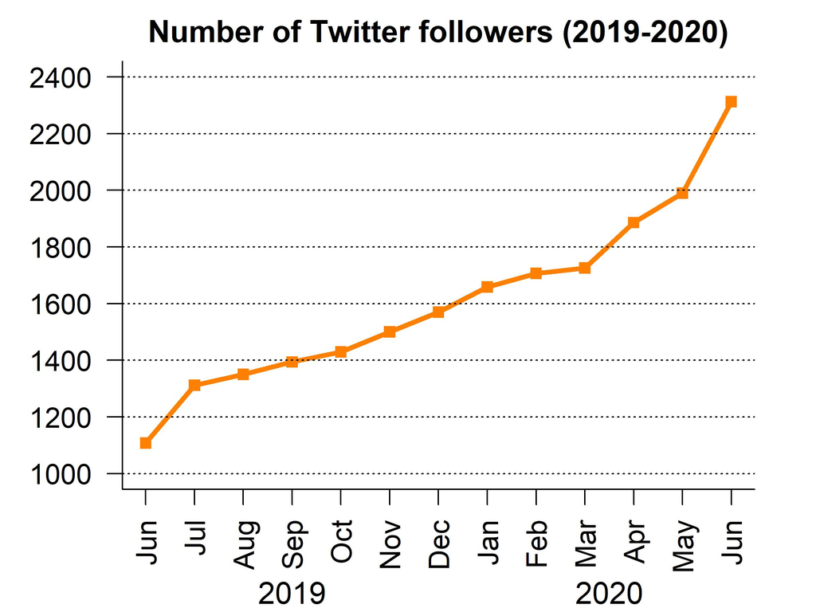

Figure 2: Evolution of the number of followers of the eRum Twitter page from June 2019 to June 2020.

The creation of the e-Rum2020 YouTube channel was instrumental to support the virtual event. To increase e-Rum2020’s outreach, we recorded 5 interviews with the keynote speakers that were published prior to the conference. The interviews were intentionally informal and provided a relaxed narration of personal experiences and R-related stories of the speakers. The channel was also used to stream plenary sessions live during the event, and to publish recordings of all conference sessions after the end of the event. In total, the channel currently hosts 59 videos organized in 12 playlists, with a total of 36 hours of edited material uploaded.

# Scientific Program

The Scientific Program of e-Rum2020 comprised several types of sessions, which ranged from keynote and invited sessions to different types of contributed sessions (workshops, regular talks, lightning talks, shiny demos and posters). All sessions were organized around a 4-days schedule, with the last day entirely dedicated to the workshops. Moreover, the conference was preceded by two satellite events: the CovidR pre-conference event, and a hackathon on spatial networks.

To ensure a balanced representation of the main fields of application of R, we identified 6 tracks that were used to guide the selection of both keynote and invited speakers, and of contributed sessions. The tracks were: Machine Learning and Modelling, R World, Applications, Life Sciences, Data Visualization and R in Production.

## Contributed sessions

The call for contributed sessions was opened on December 11, 2019, and closed on January 29, 2020, well before the outbreak of the pandemic in Europe. Abstracts were submitted through the Sessionize system, which offered a number of features for handling mass communications with users, but was lacking a simple yet efficient mechanism for evaluation, with the widely used 1-5 notes for scoring each contribution. We therefore decided to complement it by developing assessR (https://github.com/Milano-R/assessr), a Shiny app that seamlessly displayed the most relevant information for each abstract. The app kept the author information hidden, as we believed that a blinded procedure would encourage reviewers to assess the content in a fairer way.

For the evaluation of the submitted abstracts, we created a Program Committee (PC) whose members were selected in representation of the conference tracks, and were asked to score contributions specific to their field of expertise. The PC members were: Aldo Solari, Enrico Deusebio, Charlotte Soneson, Branko Kovac, Andrie De Vries, Fulvia Pennoni, Goran Milovanović, Davide Cittaro, Hannah Frick, Adolfo Alvaro, Olga Mierzwa-Sulima, Gergely Daróczi, Piercesare Secchi, Diane Beldame, Xavier Adam, Davide Risso, Pier Luca Lanzi, Levi Waldron, Heather Turner, Martin Mächler, Stefano Maria Iacus.

We received a total of 230 contributions (Figure 3), of which 32 for workshops. Of these, 94 (including 11 workshops) were selected for presentation at e-Rum2020. All contributed sessions, with the exception of workshops, were organized in two parallel tracks (later assigned to specific rooms in the system provided by Hopin), spread over 3 days. A separate day was dedicated to the workshops.

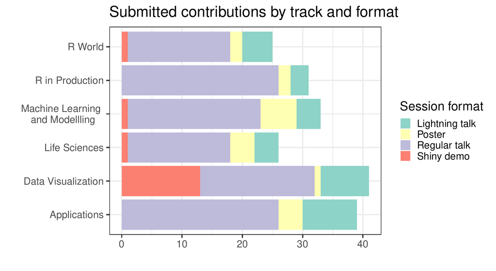

Figure 3: Submitted contributions by track and session type.

## Definition of the final program

The final lineup of talks and contributions reflected a nice balance across the six tracks. As we expected that due to the online format participants might have been able to join and stay focused for shorter stretches of time, we decided to shorten the length of all talks.

Each session type was linked to a specific room configuration for Q&As: for example, invited speakers had the possibility to individually host people at a virtual table, while panel Q&A sessions were organized for regular and lightning talks. Considering the time zones of our speakers was another important aspect to take into account. Most contributed sessions were submitted from Europe, but we were also able to accommodate late afternoon slots from the Pacific Time Zone.

Titles, abstracts and authors of each contribution, arranged by format, were published as a booklet using *bookdown* (https://2020.erum.io/program/contributed-sessions). That choice made easy and flexible its updates, progressively following confirmations, renunciations and possible changes. The final program of e-Rum2020, comprehensive of the conference schedule, was then published as a brochure (https://2020.erum.io/program).

## Hackathon on spatial networks

The beginning of e-Rum2020 was preceded by a satellite event on spatial networks that was held the day before the conference. The event comprised an online webinar and a hackathon, and it focused on introducing and testing *sfnetworks*, a new R package for the analysis of spatial networks. The satellite event was organized by Andrea Gilardi, Lorena Abad, Robin Lovelace and Lucas van der Meer.

## CovidR pre-conference event

A significant addition to e-Rum2020, decided alongside with the transition to a virtual conference, was CovidR: a contest and pre-conference event featuring open-source R contributions around the topic of the COVID-19 pandemic. Since the beginning of the pandemic, the R community has been very active in using R for analyzing data, developing models and providing useful visualizations. The idea behind CovidR was to collect such contributions and motivate the community to share and spread their work through a contest.

The CovidR submission process was based on a GitHub repository (https://github.com/Milano-R/erum2020-covidr-contest) and a streamlined Pull Request mechanism, from which we constructed an R Markdown gallery website (https://milano-r.github.io/erum2020-covidr-contest). The website gallery was constructed using the R package *rmdgallery* (https://riccardoporreca.github.io/rmdgallery), which was developed alongside the contest. The gallery allowed community engagement through the possibility of thumb-up voting submitted contributions.

Out of the 35 submissions to the contest, 15 were selected to be presented at the CovidR pre-conference event, which was held on May 29, 2020. The event featured 5-minute-long presentations and virtual round tables for Q&As, with awards granted based on the overall quality of the contributions, as well as on community feedback. The two winners of the contest were invited to give an extended presentation of their work at e-Rum2020.

A secondary, but important aspect of this pre-conference was that it enabled us to test the technical tools and the overall process of running a large virtual event. The technical preparation and smoothness of the main conference owe a lot to the lessons learned and confidence gained during CovidR.

# e-Rum2020 in figures

Conference tickets were sold out, with 2000 registered participants. After registration, 1379 participants actively attended the conference. The CovidR pre-conference event and the workshops were respectively attended by 171 and 513 participants. Figure 4 shows the geographic distribution of the conference attendees.

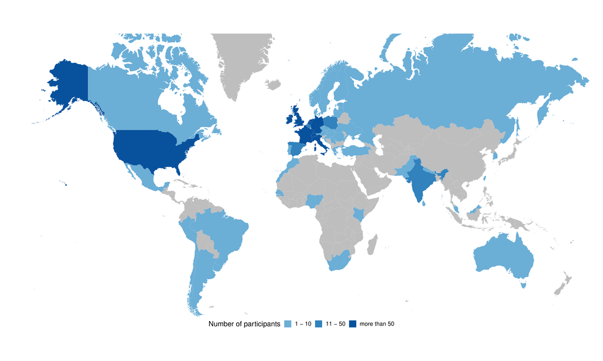

Figure 4: Geographic distribution of the attendees of e-Rum2020.

The program consisted of 104 speakers, among which 6 keynote speakers, 12 invited speakers, and 86 contributed talks. The contributed talk included 39 regular talks, 23 lightning talks, 11 Shiny demos and 13 poster presentations.

The conference staff was entirely composed by volunteers. It counted 21 Organizing Committee members, 21 Program Committee members, 23 session chairs, 7 Q&A assistants, 7 technical support assistants and 1 social media assistant.

# Organizers

e-Rum2020 was jointly organized by the e-Rum2020 Organizing Committee, the MilanoR association, two universities (Università di Milano-Bicocca and Politecnico di Milano), and two data science firms (VanLog and Mirai Solutions). The event received the patronage of Comune di Milano.

The Organizing Committee of e-Rum2020 consisted of 21 volunteers based in 5 different European countries (Italy, Switzerland, Belgium, The Netherlands and Germany): Mariachiara Fortuna, Francesca Vitalini, Emanuela Furfaro, Mirko Signorelli, Federico Marini, Riccardo L. Rossi, Roberta Sirovich, Andrea Meloncelli, Lorenzo Salvi, Riccardo Porreca, Andrea Guzzo, Gert Janssenswillen, Serena Signorelli, Filippo Chiarello, Matteo Pelagatti, Gabriele Orlando, Matteo Borrotti, Laura Terzera, Marta Galvani, Matteo Fontana and Parvaneh Shafiei.

# Sponsors

We would like to thank all the sponsors that supported the organization of e-Rum2020: RStudio, Open Analytics, cynkra, the R Consortium, the SDG group, Revelo Datalabs, SolidQ, Appsilon Data Science, datahouse and Kode, as well as our in-kind sponsors StickerMule and CRC Press.

# Acknowledgments

As members of the e-Rum2020 Organizing Committee, we would like to thank all the volunteers that contributed to the success of e-Rum2020: the Program Committee members, keynote, invited and contributed speakers, and all the volunteers that helped as session chairs, or helped managing the Q&A, technical support for attendees and social media coverage during the event.

# Links

Further information about e-Rum2020 and the contributions presented during the conference can be found at the following links:

1. conference website: https://2020.erum.io
2. e-Rum2020 Youtube channel: https://www.youtube.com/c/eRum2020
3. conference materials: https://github.com/Milano-R/erum2020program#readme
4. CovidR gallery with all submissions for the CovidR pre-conference event: https://milano-r.github.io/erum2020-covidr-contest
5. AssessR shiny app: https://github.com/Milano-R/assessr

Beresewicz, Maciej, Adolfo Alvarez, Przemysław Biecek, Marcin K Dyderski, Marcin Kosinski, Jakub Nowosad, Kamil Rotter, et al. 2017. “Conference Report: European R Users Meeting 2016.” *R Journal* 9 (1).

Daróczi, Gergely. 2018. “Conference Report: ERum 2018.” *R Journal* 10 (1).